# DATA607-PROJECT2

Biyag Dukuray and Rashad Long

2024-02-24

## DATA-607 Project 2

IS 607 – Project 2 The goal of this assignment is to give you practice in preparing different datasets for downstream analysis work. Your task is to: (1) Choose any three of the “wide” datasets identified in the Week 6 Discussion items. (You may use your own dataset; please don’t use my Sample Post dataset, since that was used in your Week 6 assignment!) For each of the three chosen datasets: Create a .CSV file (or optionally, a MySQL database!) that includes all of the information included in the dataset. You’re encouraged to use a “wide” structure similar to how the information appears in the discussion item, so that you can practice tidying and transformations as described below. Read the information from your .CSV file into R, and use tidyr and dplyr as needed to tidy and transform your data. [Most of your grade will be based on this step!] Perform the analysis requested in the discussion item. Your code should be in an R Markdown file, posted to rpubs.com, and should include narrative descriptions of your data cleanup work, analysis, and conclusions.

**Source: 2021 Fifa player data.** **We will begin the tidying of this data set by loading the necessary libraries as well as loading the raw csv file into a data frame. We then store the data in a data frame which we will call fifaplayer_data.**

```r
library(tidyverse)
library(dplyr)

fifaraw_data <- "https://raw.githubusercontent.com/Zcash95/DATA607-Project2/main/fifa21_raw_data.csv"

fifaplayer_data <- read.csv(fifaraw_data, header = TRUE, sep = ",")


head(fifaplayer_data)
```

```
##                                           photoUrl                     LongName
## 1 https://cdn.sofifa.com/players/158/023/21_60.png                 Lionel Messi
## 2 https://cdn.sofifa.com/players/020/801/21_60.png C. Ronaldo dos Santos Aveiro
## 3 https://cdn.sofifa.com/players/200/389/21_60.png                    Jan Oblak
## 4 https://cdn.sofifa.com/players/192/985/21_60.png              Kevin De Bruyne
## 5 https://cdn.sofifa.com/players/190/871/21_60.png   Neymar da Silva Santos Jr.
## 6 https://cdn.sofifa.com/players/188/545/21_60.png           Robert Lewandowski
##                                                            playerUrl
## 1               http://sofifa.com/player/158023/lionel-messi/210005/
## 2 http://sofifa.com/player/20801/c-ronaldo-dos-santos-aveiro/210005/
## 3                  http://sofifa.com/player/200389/jan-oblak/210005/
## 4            http://sofifa.com/player/192985/kevin-de-bruyne/210005/
## 5  http://sofifa.com/player/190871/neymar-da-silva-santos-jr/210005/
## 6         http://sofifa.com/player/188545/robert-lewandowski/210005/
##   Nationality Positions              Name Age X.OVA POT
```

[output cut: 69 more lines]

**We will then continue to remove the columns which are not necessary to perform our analysis. This dataset contains 77 columns which many are added and combined in the total stats column. Because of this we can remove the columns containing individual stats which are not required for our analysis.**

```r
columns_to_remove <- c(23:63, which(names(fifaplayer_data) %in% c("photoUrl", "playerUrl", "Hits")))

fifaplayer_data1 <- fifaplayer_data %>%
  select(-columns_to_remove)
str(fifaplayer_data1)
```

```
## 'data.frame':    18979 obs. of  33 variables:
##  $ LongName       : chr  "Lionel Messi" "C. Ronaldo dos Santos Aveiro" "Jan Oblak" "Kevin De Bruyne" ...
##  $ Nationality    : chr  "Argentina" "Portugal" "Slovenia" "Belgium" ...
##  $ Positions      : chr  "RW ST CF" "ST LW" "GK" "CAM CM" ...
##  $ Name           : chr  "L. Messi" "Cristiano Ronaldo" "J. Oblak" "K. De Bruyne" ...
##  $ Age            : int  33 35 27 29 28 31 21 27 28 28 ...
##  $ X.OVA          : int  93 92 91 91 91 91 90 90 90 90 ...
##  $ POT            : int  93 92 93 91 91 91 95 91 90 90 ...
##  $ Team...Contract: chr  "\n\n\n\nFC Barcelona\n2004 ~ 2021\n\n" "\n\n\n\nJuventus\n2018 ~ 2022\n\n" "\n\n\n\nAtlético Madrid\n2014 ~ 2023\n\n" "\n\n\n\nManchester City\n2015 ~ 2023\n\n" ...
##  $ ID             : int  158023 20801 200389 192985 190871 188545 231747 212831 209331 208722 ...
##  $ Height         : chr  "5'7\"" "6'2\"" "6'2\"" "5'11\"" ...
##  $ Weight         : chr  "159lbs" "183lbs" "192lbs" "154lbs" ...
##  $ foot           : chr  "Left" "Right" "Right" "Right" ...
##  $ BOV            : int  93 92 91 91 91 91 91 90 90 90 ...
##  $ BP             : chr  "RW" "ST" "GK" "CAM" ...
```

[output cut: 19 more lines]

```r
head(fifaplayer_data1)
```

```
##                       LongName Nationality Positions              Name Age
## 1                 Lionel Messi   Argentina  RW ST CF          L. Messi  33
## 2 C. Ronaldo dos Santos Aveiro    Portugal     ST LW Cristiano Ronaldo  35
## 3                    Jan Oblak    Slovenia        GK          J. Oblak  27
## 4              Kevin De Bruyne     Belgium    CAM CM      K. De Bruyne  29
## 5   Neymar da Silva Santos Jr.      Brazil    LW CAM         Neymar Jr  28
## 6           Robert Lewandowski      Poland        ST    R. Lewandowski  31
##   X.OVA POT                              Team...Contract     ID Height Weight
## 1    93  93        \n\n\n\nFC Barcelona\n2004 ~ 2021\n\n 158023   5'7" 159lbs
## 2    92  92            \n\n\n\nJuventus\n2018 ~ 2022\n\n  20801   6'2" 183lbs
## 3    91  93     \n\n\n\nAtlético Madrid\n2014 ~ 2023\n\n 200389   6'2" 192lbs
## 4    91  91     \n\n\n\nManchester City\n2015 ~ 2023\n\n 192985  5'11" 154lbs
## 5    91  91 \n\n\n\nParis Saint-Germain\n2017 ~ 2022\n\n 190871   5'9" 150lbs
## 6    91  91   \n\n\n\nFC Bayern München\n2014 ~ 2023\n\n 188545   6'0" 176lbs
##    foot BOV  BP Growth       Joined Loan.Date.End  Value  Wage Release.Clause
## 1  Left  93  RW      0  Jul 1, 2004           N/A €67.5M €560K        €138.4M
## 2 Right  92  ST      0 Jul 10, 2018           N/A   €46M €220K         €75.9M
## 3 Right  91  GK      2 Jul 16, 2014           N/A   €75M €125K        €159.4M
## 4 Right  91 CAM      0 Aug 30, 2015           N/A   €87M €370K          €161M
## 5 Right  91  LW      0  Aug 3, 2017           N/A   €90M €270K        €166.5M
## 6 Right  91  ST      0  Jul 1, 2014           N/A   €80M €240K          €132M
##   Total.Stats Base.Stats W.F SM    A.W    D.W  IR PAC SHO PAS DRI DEF PHY
## 1        2231        466 4 ★ 4★ Medium    Low 5 ★  85  92  91  95  38  65
## 2        2221        464 4 ★ 5★   High    Low 5 ★  89  93  81  89  35  77
## 3        1413        489 3 ★ 1★ Medium Medium 3 ★  87  92  78  90  52  90
## 4        2304        485 5 ★ 4★   High   High 4 ★  76  86  93  88  64  78
## 5        2175        451 5 ★ 5★   High Medium 5 ★  91  85  86  94  36  59
## 6        2195        457 4 ★ 4★   High Medium 4 ★  78  91  78  85  43  82
```

```r
fifaplayer_data1$Value <- as.numeric(gsub("[^0-9.]", "", fifaplayer_data1$Value))

fifaplayer_data1$Total.Stats <- as.numeric(fifaplayer_data1$Total.Stats)

fifaplayer_data1$Proportion <- fifaplayer_data1$Total.Stats / fifaplayer_data1$Value

complete_rows <- complete.cases(fifaplayer_data1[, c("Total.Stats", "Value")])
```

**We first summarize the data and can see that the average total stats of players is a score of 1595. This will help us better gauge a players performance just by taking an initial look at it. We complete this by creating a scatter plot to visualize the value of contracts in comparison with that players stats performance on fifa”**

```r
summary(fifaplayer_data1$`Total.Stats`)
```

```
##    Min. 1st Qu.  Median    Mean 3rd Qu.    Max.
##     747    1452    1627    1595    1781    2316
```

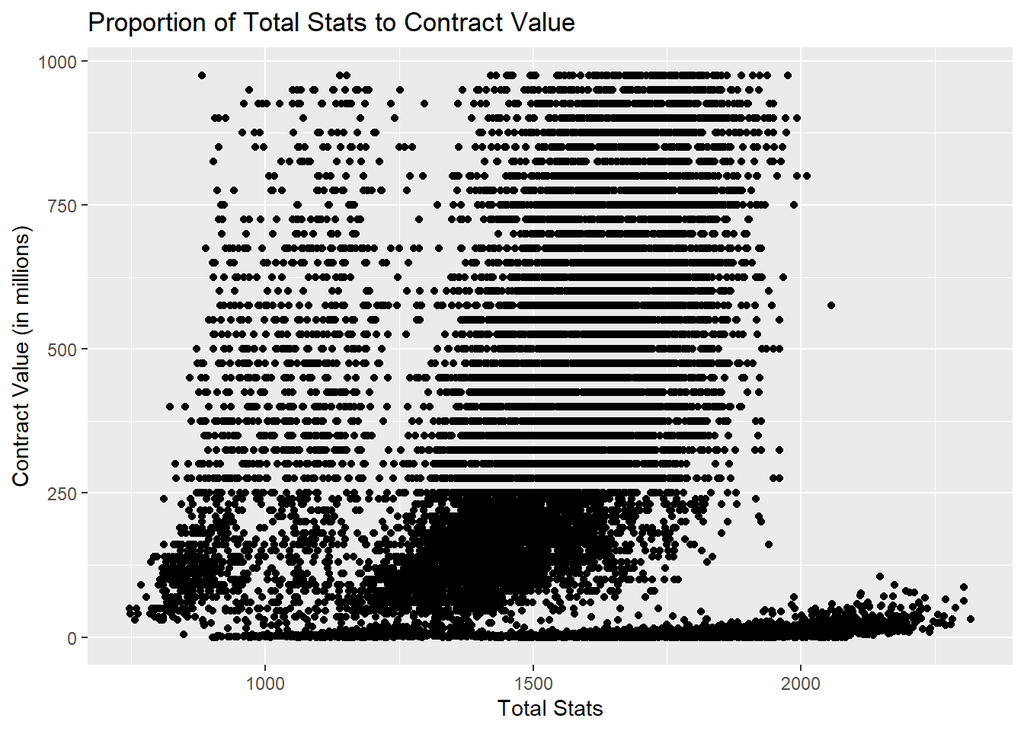

```r
ggplot(fifaplayer_data1[complete_rows,], aes(x = Total.Stats, y = Value)) +
  geom_point() +
  labs(title = "Proportion of Total Stats to Contract Value",
       x = "Total Stats",
       y = "Contract Value (in millions)")
```